# Unit 6

### Training Concept

Training is a critical phase in the implementation of new systems, focusing on equipping users and operators with the knowledge and skills needed to effectively use and maintain the system. Proper training ensures successful adoption, efficient use, and increased productivity.

#### **Importance of Training**

- Ensures smooth transition from the old system to the new one.
- Facilitates successful implementation by preparing users and operators.
- Mitigates resistance to changes brought by the new system.
- Enhances productivity by improving user familiarity and confidence.
- Promotes ownership and acceptance of the new system.

#### **Components of a Training Program**

1. **General Information:** Provide an overview of the system and its purpose.
2. **Specific Operations:** Explain detailed steps for operating the system.
3. **Hands-On Practice:** Allow users to practice system operations.
4. **Feedback Mechanisms:** Offer opportunities for user feedback to address concerns.
5. **Adjustment Period:** Provide time for users to adapt to the new system.
6. **Query Resolution:** Address questions and clarify doubts.
7. **Ownership Feeling:** Involve employees to make them feel the system is theirs.

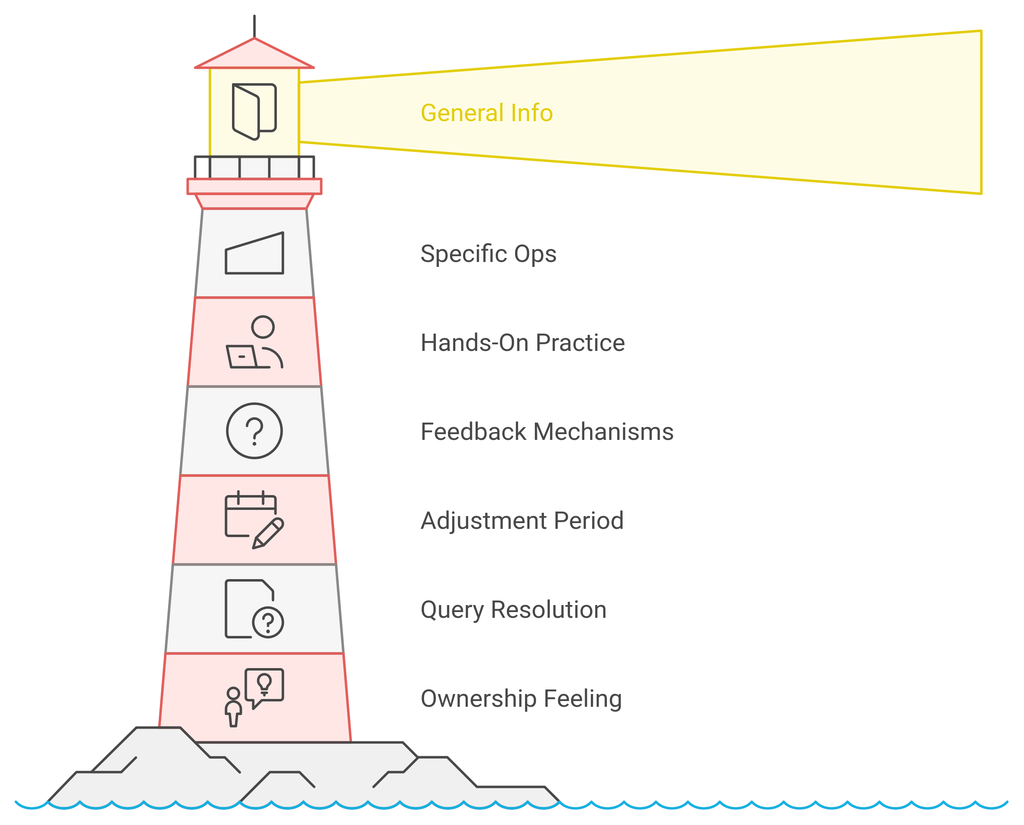

#### **User Training**

Focuses on the end users who directly interact with the system.  
- Learning basic operations (start-up, shutdown, troubleshooting).  
- Performing tasks like data coding, capturing, handling, backup, and maintenance.  
- Understanding output methods and recovery procedures.

#### **System Operator Training**

Covers tasks essential for maintaining the system’s operational integrity.  
- Installation and regular operation of the system.  
- Data entry methods and troubleshooting procedures.  
- Addressing system malfunctions.

#### **Training Methods**

1. **Vendor and In-Service Training**
   - Conducted by experienced trainers and sales personnel.
   - Provides hands-on experience and troubleshooting techniques.
   - Advantageous for networking with field professionals.
2. **In-House Training**
   - Conducted within the organization using manuals and other instructional materials.
   - Advantages: Tailored to organizational needs, cost-effective for larger groups.
   - Disadvantages: Limited hands-on training, possible distractions.